# Tanıtım

Yaşam Bilimlerinde Veri Analizi

Emrah Kırdök, Ph.D.

2023-02-03

# Hoşgeldiniz

## Ders hakkında bilgi

- Dersin internet sitesi: https://emrahkirdok.github.io/ybva/

## Ders hakkında bilgi

- R ve Rstudio programları kullanılacak.

# Neden YBVA

## Yaşam Bilimlerinde Veri Analizi

- Yaşam bilimleri alanında hızlı bir gelişme var.
- Dizileme teknolojileri sayesinde büyük miktarda veri üretildi.
- Ancak bu veriyi analiz edebilecek insan sayısı kısıtlı.
- Biz bu noktaya odaklanıyoruz.

## Örnek: Dizileme verisi

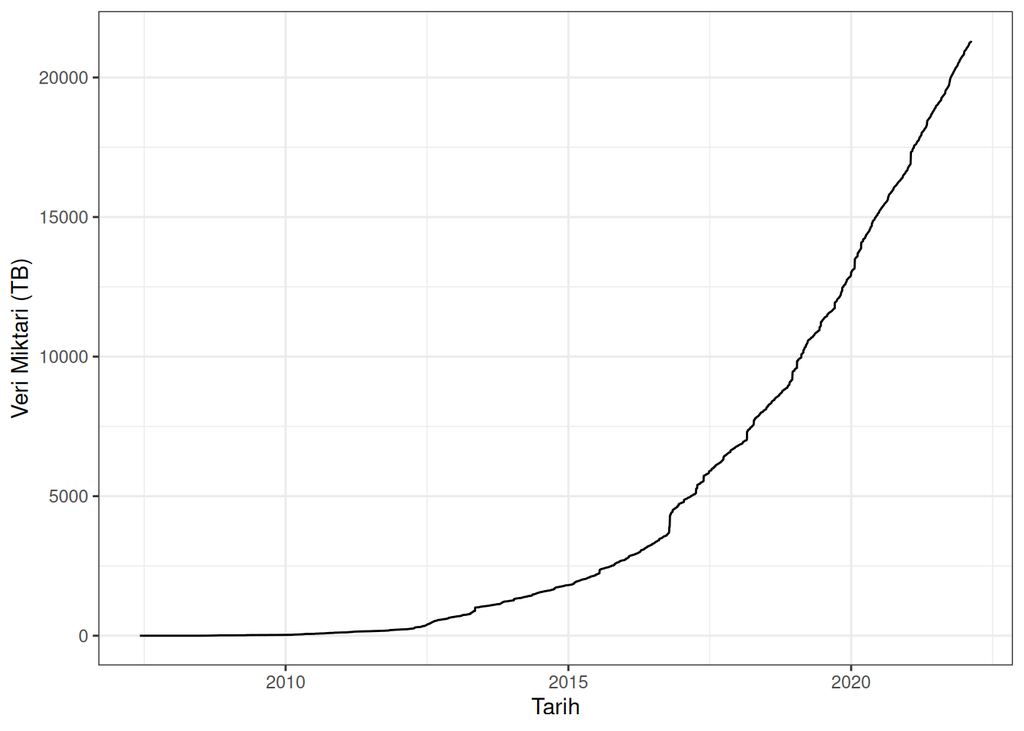

NCBI dizi okuma arşivindeki veri miktarının artışı

## Örnek: Türkiye deprem verisi

- Sadece biyolojik veri olmasına gerek yok.
- Artık bir veri dünyasında yaşıyoruz.
- Mesela Türkiye ve çevresindeki depremleri incelemek ister misiniz?

## Örnek: Türkiye deprem verisi

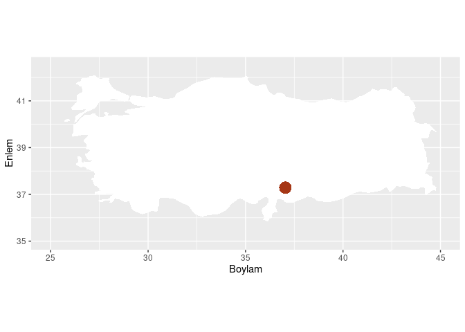

Deprem verisini analiz etmek ister misiniz?

# Veri Bilimi

## Yeni bir bakış açısı

- Artan veri miktarı yeni bir bakış açısını gerekli kıldı.
- Artık veri üzerinde çalışıyoruz.

## Kısıt!

- Ancak bu kadar veriyi analiz edecek insan sayısı az!
- Geleceğin mesleği (On yıl sonra yerini başka bir geleceğin mesleğine devretmek üzere!)

# Neden Veri Bilimi?

## Verinin sakladığı gizemler

- Bilimsel yöntem genelde gözlemden sonuca gider.
- Ancak artık sonuçtan gözleme gidiyoruz!
- Ancak özel ekipman kullanmamız gerekli.

## Havalı bir meslek!

[figure not shown]

## Chandler Bing’in mesleği

[figure not shown]

# Bilgisayarlar

## Bilgisayarlar

- Adı üstünde bilgi sayar.
- Temel işi saymak.
- Sadece sayısal bilgi işleyebilir.
- Genelde sayılar bir şeyleri temsil eder.

## Sayılar neyi temsil eder?

Harfleri:

- A, B, C, D, E…

Notaları

## Sayılar neyi temsil eder?

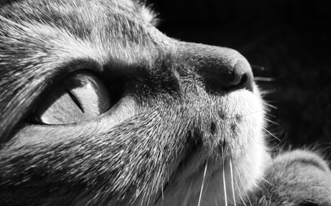

Kedileri?

## Sayılar neyi temsil eder?

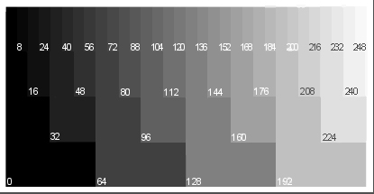

Gri tonlama

## Sayılar neyi temsil eder?

DNA’yı:

TCTAGCTAGCTAGCTAGCTAGC TAGCTAGCTAGCTAGCTAGCTA GCTAGCTAGTCAGTCGTACGTA GCTAGCTAGCTAGCTAGTCGAT CGATCA

## Sayılar neyi temsil eder?

Proteinleri:

QYINQSICIIYYMCTIKFSLWF LPGTKVCRCPVIQYDKFTRGYG LACTEEVATAQRYSRTIVRLWC EPKNRHCRGRDKNEGSLHASMF YQDTCWDDPYRLFKERYRCMPT NAQLTWTYYW

## Bilgisayarlar bu verilerle ne yapar?

Veriler bilgisayarlar yardımıyla işlenir.

Bir konumdan başka bir konuma iletilir ve dönüştürülür.

Verilerin uzun süreli depolanmasını sağlar.

## Bilgisayarlar

[figure not shown]

## CPU

Bilgisayarın temel bilgi işleme birimidir.

Bütün parçalar arasındaki koordinasyonu sağlamaktan sorumludur.

**Bir orkestra şefi gibi**

## RAM

Rastgele hafıza erişimi (Random Access Memory).

Bilgisayardaki birincil hafıza birimidir. Sadece aktif olarak kullanılan veriler depolanır.

Ancak kısa sürelidir ve kalıcılığı yoktur. Enerji kesildiğinde silinir.

## Harddisk

İkincil depolama birimi olarak kullanılır.

Uzun süreli bir depolama sağlar.

Ucuz ancak yavaş bir depolama birimidir.

## Dosyalar

Sayıları depoladığımız listeler. Her dosyanın:

- ismi,
- oluşturulma tarihi,
- boyutu,
- kullanım hakları

bulunur

## Dosya isimleri

Bir karakter listesinde:

- harfler,
- numaralar,
- semboller bulunabilir
- ve 250 karater uzunluğunda olabilir

Aşağıdakiler hariç:

- **Türkçe karakter ve boşluk!**
- **/, :, +, |, <, *, >, ” ve ’ **

## Dosya isimleri

Unix/Linux sistemlerde büyük ve küçük harfler farklıdır.

Her dosyanın uzantısı vardır (zorunlu değil ama anlaşılmayı kolaylaştırır):

- .exe
- .jpg
- .doc
- .txt

## Dosya tipleri

Temel olarak iki tip dosya var:

- Metin dosyaları
  - Sadece düz metin içerirler.
  - Anlaşılabilirdir.
- İkili dosyalar
  - Sayısal bilginin ikili şekilde düzenlenmiş halidir.
  - Ses, resim dosylaları.

## Metni ifade etmek

İngilizce için ASCII isimli bir kodlama var.

Sıfır - 127 arasındak her numara bir *sembol* veya bir *sinyal* olarak ifade edilir:

- Yeni satır
- Tab
- Boşluk
- Silme tuşu

## ASCII code

|  | 30 | 40 | 50 | 60 | 70 | 80 | 90 | 100 | 110 | 120 |
| --- | --- | --- | --- | --- | --- | --- | --- | --- | --- | --- |
| 0 |  | ( | 2 | < | F | P | Z | d | n | x |
| 1 |  | ) | 3 | = | G | Q | [ | e | o | y |
| 2 |  |  | 4 | > | H | R | \ | f | p | z |
| 3 | ! | + | 5 | ? | I | S | ] | g | q | { |
| 4 | ” | , | 6 | @ | J | T | ^ | h | r | \| |
| 5 | # | - | 7 | A | K | U |  | i | s | } |
| 6 | $ | . | 8 | B | L | V | ` | j | t | ~ |
| 7 | % | / | 9 | C | M | W | a | k | u |  |
| 8 | & | 0 | : | D | N | X | b | l | v |  |
| 9 | ´ | 1 | ; | E | O | Y | c | m | w |  |

Non-English languages use numbers between 128 and 255 for symbols like “Ç”, “Ö”, “É”, “Ñ”. *(İngilizce dışındaki dillerde “Ç”, “Ö”, “É”, “Ñ” gibi semboller için 128 ile 255 arasındaki sayılar kullanılır)*

## Metin dosyaları

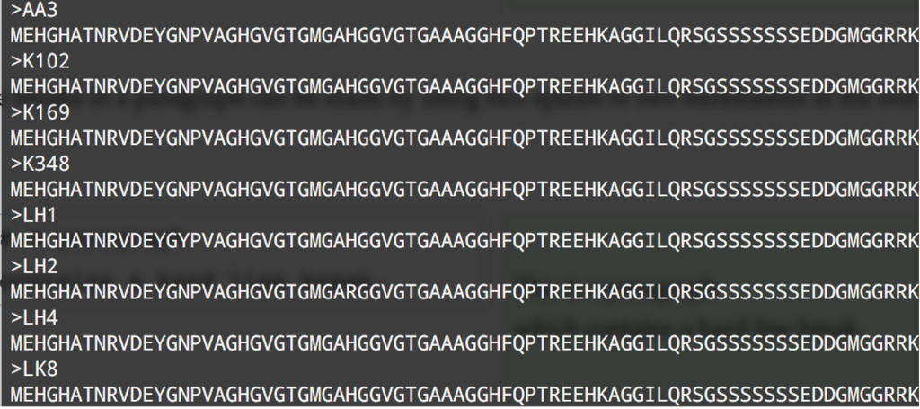

## İkili dosyalar

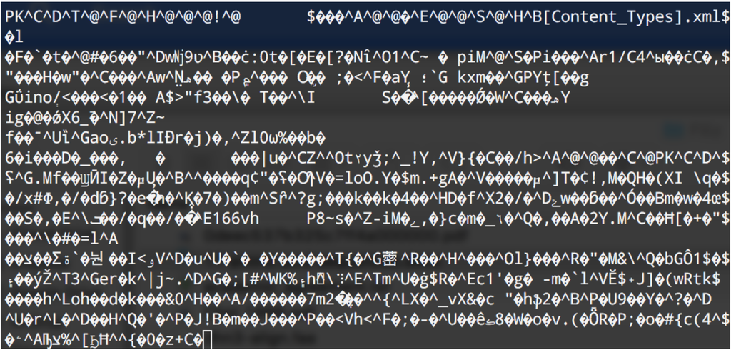

# R ve RStudio

## Yeni bir çalışma biçimi

[figure not shown]

## Başlangıçlar hep zor!

[figure not shown]